# Notes on R programming language

### Set environment for the session

- `Sys.setlocale("LC_CTYPE", "russian")` is useful for handling texts in Russian
- `options(stringsAsFactors = F)`
- `options(error=recover)` is useful for debugging

### Editing text variable

- `sprintf("%s/%s/", path, cand)` returns “path/cand”
- `dput()` returns an ASCII text representation of an R object.

```r
dput(names(mtcars))
```

```
## c("mpg", "cyl", "disp", "hp", "drat", "wt", "qsec", "vs", "am",
## "gear", "carb")
```

### Combinatorics

- `expand.grid()` creates a data frame from all combinations of the supplied vectors or factors

### R-markdown

- making tables with `xtable`

```r
fit <- lm(Ozone ~ Wind + Temp +Solar.R, data = airquality)
```

Print the table with regression coefficients.

```r
require(xtable)
xt <- xtable(summary(fit))
print(xt, type = "html")
```

|  | Estimate | Std. Error | t value | Pr(>\|t\|) |
| --- | --- | --- | --- | --- |
| (Intercept) | -64.3421 | 23.0547 | -2.79 | 0.0062 |
| Wind | -3.3336 | 0.6544 | -5.09 | 0.0000 |
| Temp | 1.6521 | 0.2535 | 6.52 | 0.0000 |
| Solar.R | 0.0598 | 0.0232 | 2.58 | 0.0112 |

### Exploratory Graphs

- There are 3 graphics systems that cannot be generally mixed.

#### Base plotting systems

##### Creating a plot

- `plot(x, y)` is a generic function, behaves differently depending on arguments
- `plot(x, y, type = "n")` creates empty plot
- `hist(data, breaks = 100)` produces histogram where `breaks` sets the number of bars

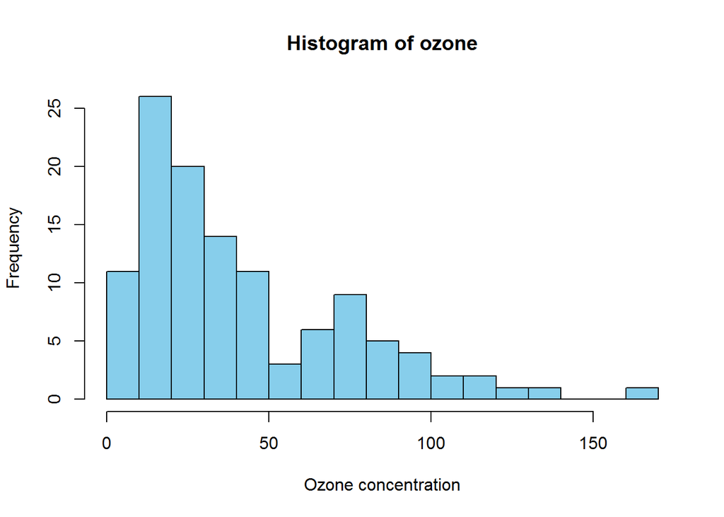

```r
library(datasets)
hist(airquality$Ozone, col = "skyblue", breaks = 20, main = "Histogram of ozone", xlab = "Ozone concentration")
```

- `lines()` adds lines to a plot
- `points()` adds points to a plot. For further references check `example(points)`

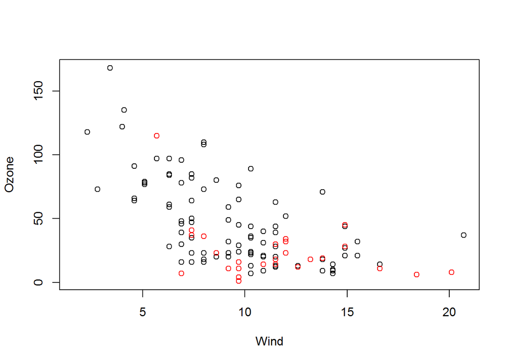

```r
with(airquality, plot(Wind, Ozone))
with(subset(airquality, Month == 5), points(Wind, Ozone, col = "red"))
```

- `boxplot(data ~ categories, data = dataset, col = "red")` produces box-and-whisker plot(s) of the given (grouped) values

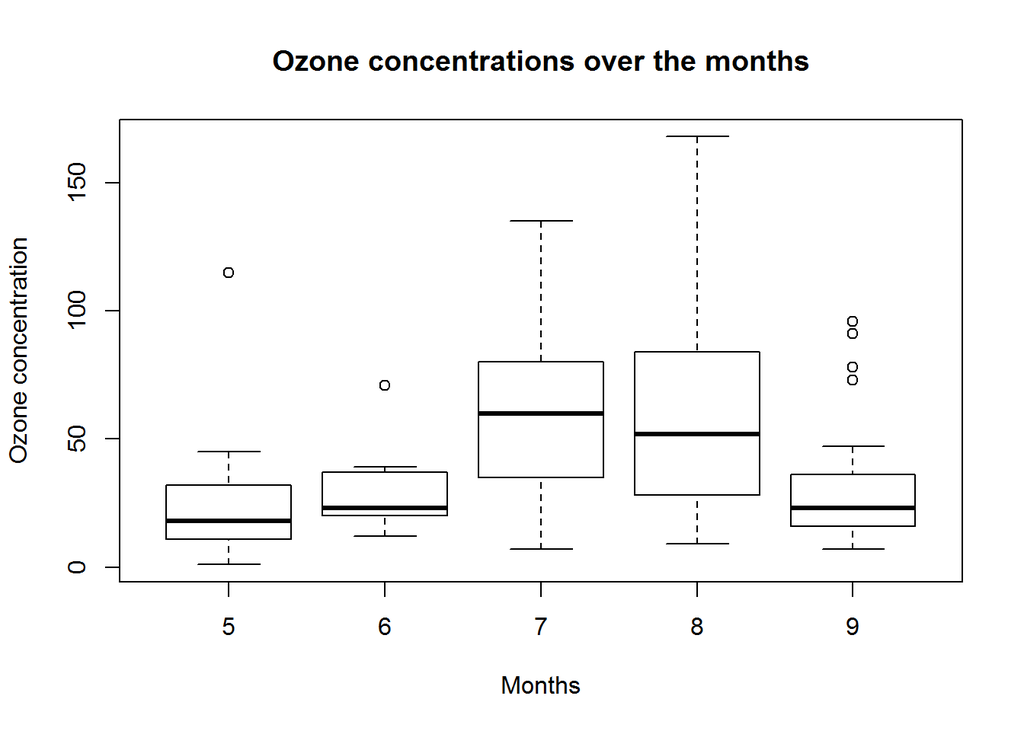

```r
boxplot(Ozone ~ Month, data = airquality, main = "Ozone concentrations over the months", xlab = "Months", ylab = "Ozone concentration")
```

- `abline()` can be used to plot **regression lines**, e.g.,

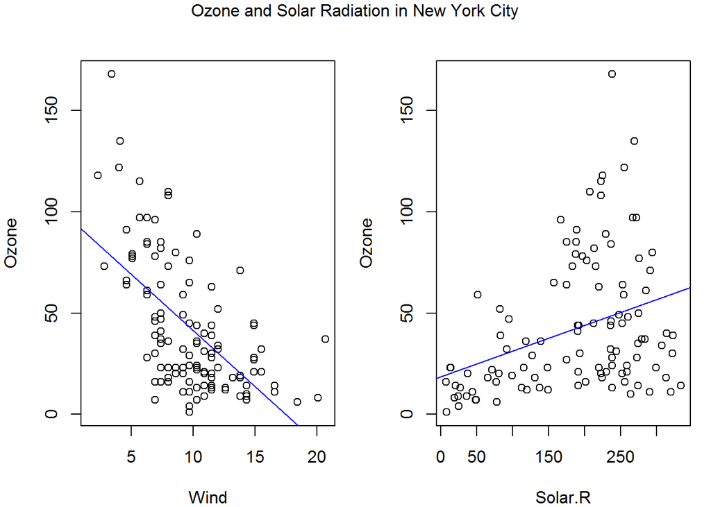

```r
model.wind <- lm(Ozone ~ Wind, airquality)
model.solar <- lm(Ozone ~ Solar.R, airquality)
par(mfrow = c(1, 2), oma = c(0, 0, 1, 0), mar = c(4, 4, 2, 1))
with(airquality, {
  plot(Wind, Ozone)
  abline(model.wind, col = "blue")
  plot(Solar.R, Ozone)
  abline(model.solar, col = "blue")
  mtext("Ozone and Solar Radiation in New York City", outer = T)
})
```

- `barplot(table(data), col = color, main = "Title of the graph")` is useful for plotting **categorical** data
- `par()` is used to set global graphical parameters, e.g.,
  - `pch` the plotting symbol
  - `lty` the line type
  - `lwd` the line width
  - `col` specifies the color (check `colors()` function)
  - `xlab` and `ylab` are character strings for the axis
  - `las` orientation of the axis labels
  - `bg` background color
  - `mar` margin size
  - `mfrow` specifies number of plots per row (plots are filled row-wise). Can be used for multiple base plots
  - `mfcol` specifies number of plots per column (plots are filled column-wise)

##### Annotating plot

- `text()` adds text labels inside the plot
- `title()` adds annotations outside the plot
- `legend()` adds legend to the plot

#### Lattice system

```r
library(lattice)
```

- good for plotting many plots on a screen
- most useful for conditioning type of plots
- plots are created with single function call
- high-level Lattice functions return an object of class “trellis”
- `xyplot(y ~ x, data)` is useful for scatterplots and time-series

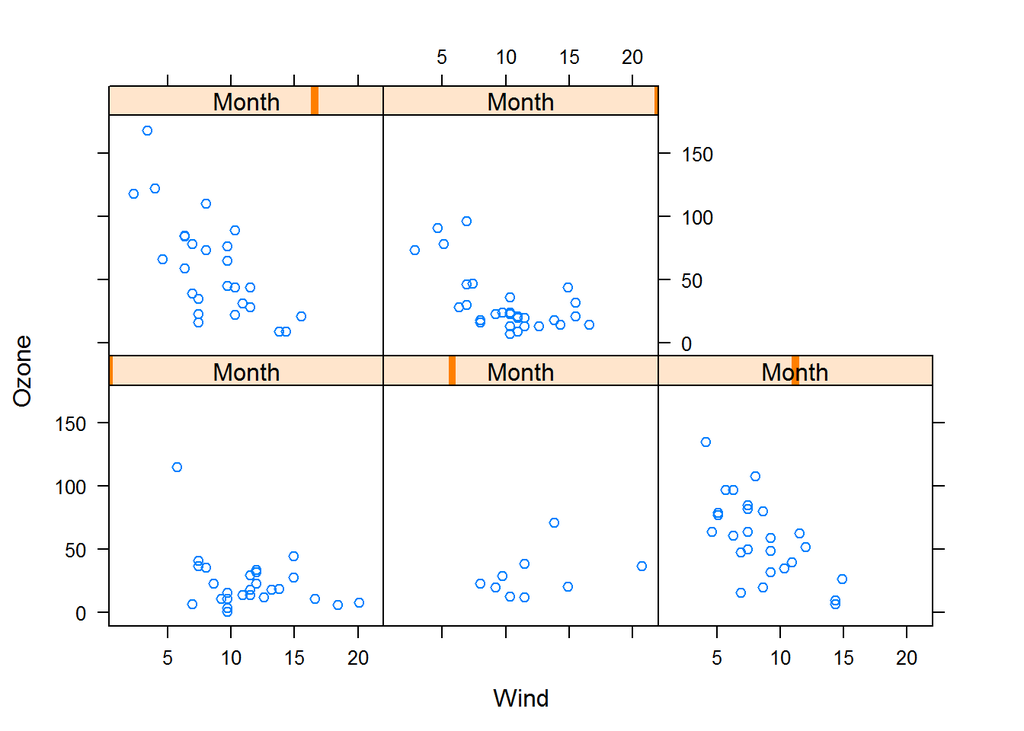

```r
xyplot(Ozone ~ Wind | Month, airquality)
```

- `bwplot()` -> box-and-whisker plots
- `histogram()` -> histograms
- `panel()` function controls what happens inside each panel of the plot

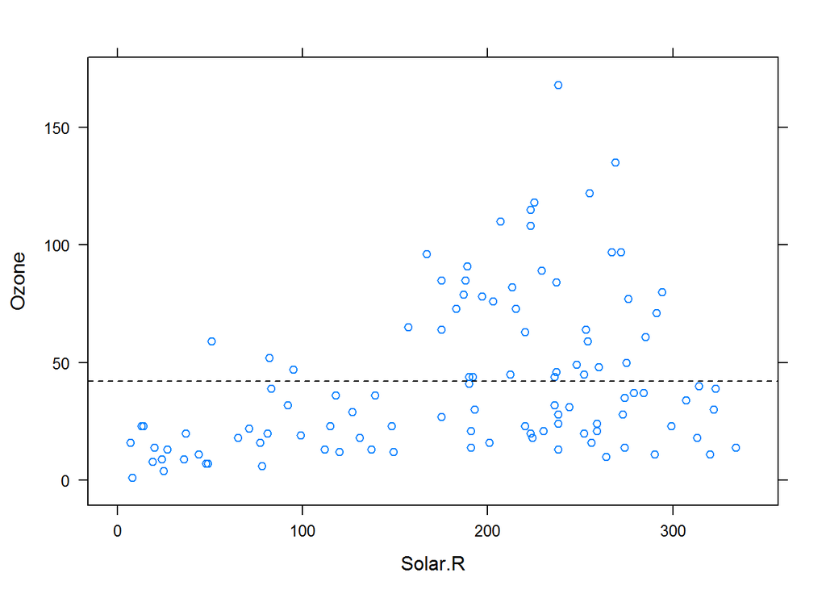

```r
#custom panel function
xyplot(Ozone ~ Solar.R, airquality, panel = function(x, y, ...){
  panel.xyplot(x, y, ...) #first call the default panel function
  panel.abline(h = mean(y, na.rm = T), lty = 2)
})
```

#### ggplot2 system

```r
library(ggplot2)
```

- an implementation of the Gramar of Graphics by Leland Wilkinson
- shorten the distance from mind to map by using `aesthetics` (size, shape, color) and `geom` (point, lines)
- data always come from data frames
- factors should be labeled intelligently
- `qplot()` is a basic plotting function, a convenient wrapper for `plot()`,
- `qplot(displ, hwy, data = mpg)` produces simple scatterplot

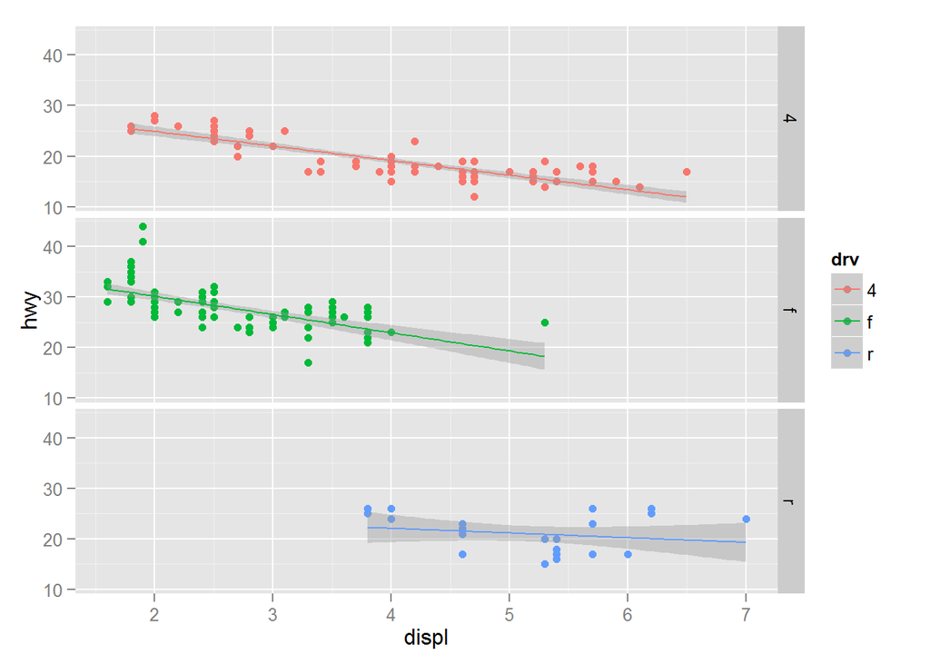

```r
qplot(displ, hwy, data = mpg, color = drv, geom = c("point", "smooth"), facets = drv ~ ., method = "lm")
```

- `qplot(x, data)` produces histogram

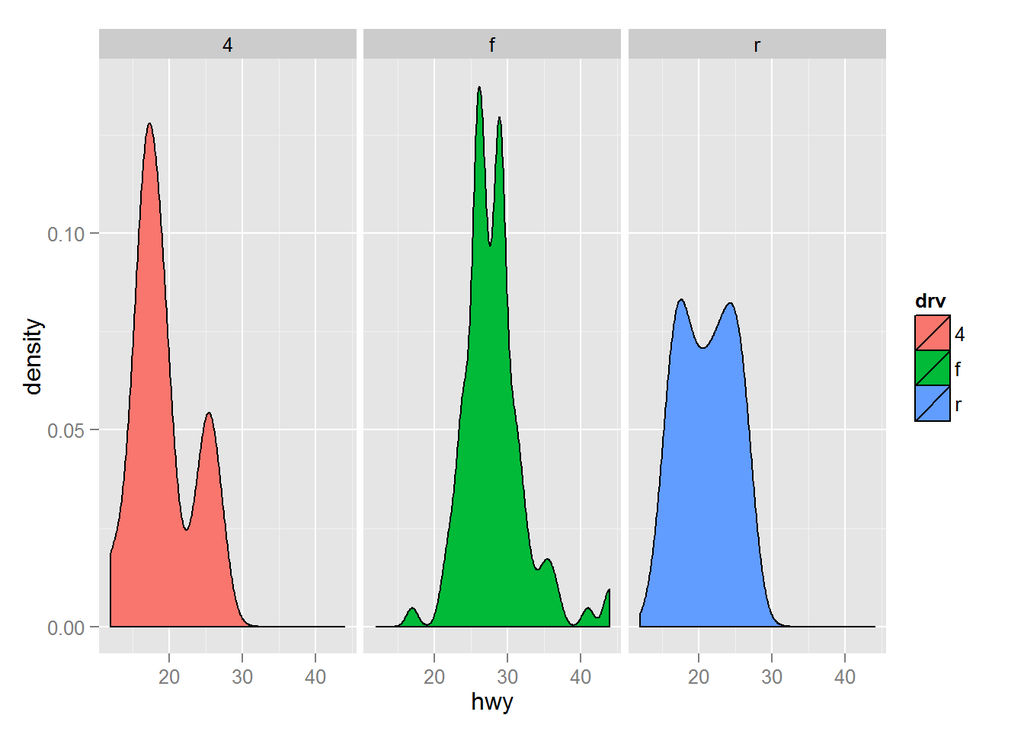

```r
qplot(hwy, data = mpg, facets = . ~ drv, fill = drv, geom = "density")
```

- `ggplot()` is core function that provides low level customization and layer by layer plotting

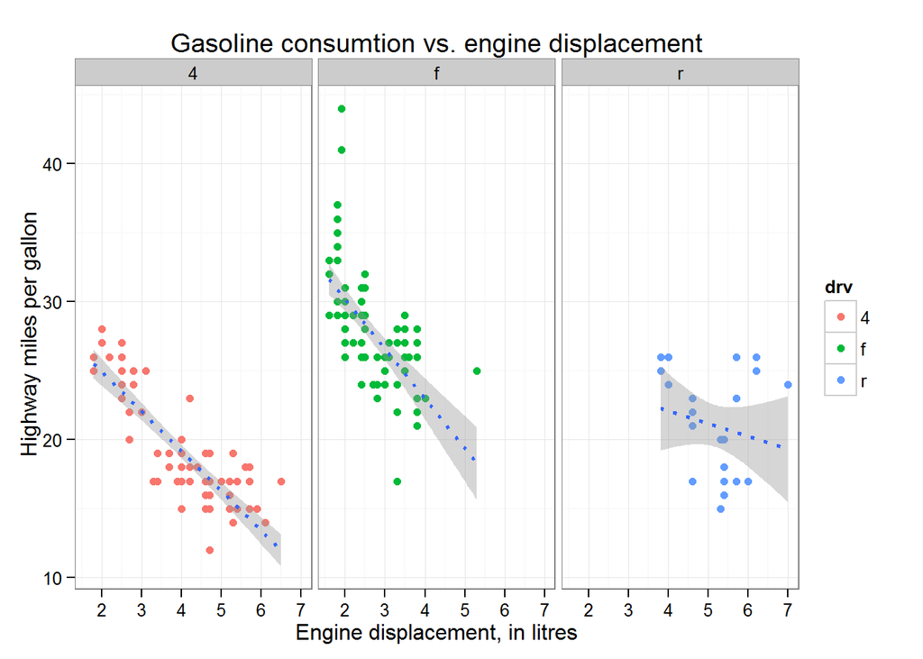

```r
g <- ggplot(mpg, aes(displ, hwy))
g + geom_point(aes(color = drv)) + facet_grid(. ~ drv) + geom_smooth(method = "lm", linetype = 3, size = 1) + labs(title = "Gasoline consumtion vs. engine displacement", x = "Engine displacement, in litres", y = " Highway miles per gallon") + theme_bw()
```

- for **annotations** use `xlabs()`, `ylabs()`, `labs()`, `ggtitle()`
- each `geom()` functions has options to change
- to specify the whole plot use `theme()` function, e.g., `theme(legend.position = 'none')`
- two standart themes are included: `theme_gray()` and `theme_bw()`
- `coord_cartesian()` is used to ignore the outlier

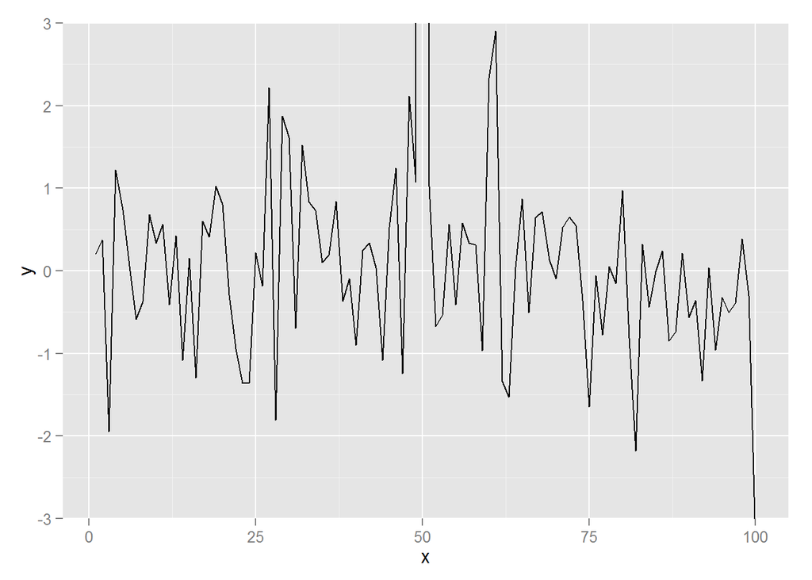

```r
#
df <- data.frame(x = 1:100, y = rnorm(100))
df[50, 2] <- 100 #outlier!
g <- ggplot(df, aes(x, y))
g + geom_line() + coord_cartesian(ylim = c(-3, 3))
```

- `cut()` allows to make continuoes variable categorical

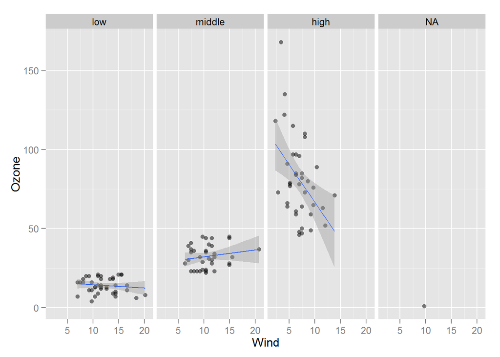

```r
#Calculate the deciles of the data
cutpoints <- quantile(airquality$Ozone, seq(0, 1, length = 4), na.rm = T)

#Cut the data and create new factor variable
airquality$O3level <- cut(airquality$Ozone, cutpoints)

#Set the descriptive levels
levels(airquality$O3level) <- c("low", "middle", "high")

#Setup ggplot() with data frame
g <- ggplot(airquality, aes(Wind, Ozone))
g + geom_point(alpha = 1/2) + facet_grid(. ~ O3level) + geom_smooth(method = "lm")
```

- `grid.arrange()` from package `gridExtra` sets up a gtable layout to place multiple grobs on a page

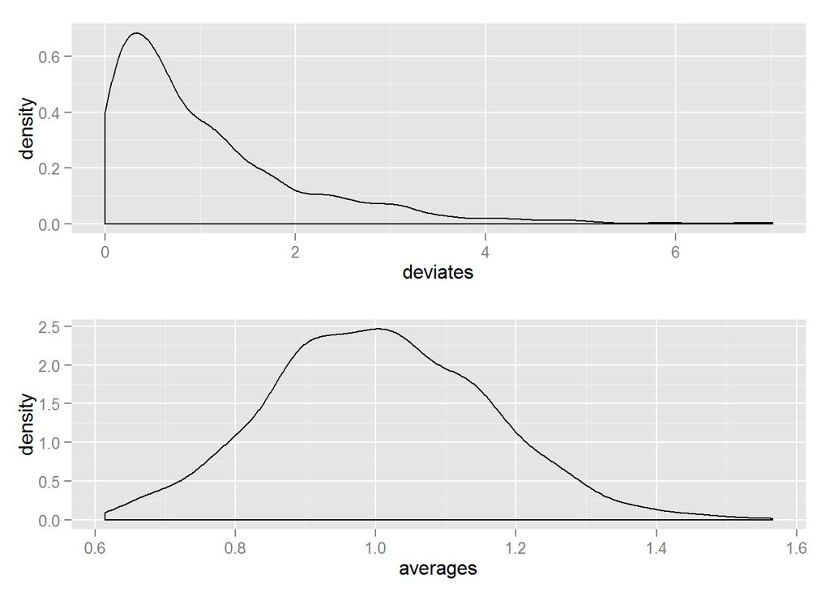

```r
library(gridExtra)
p1 <- qplot(rexp(1000), geom = "density", xlab = "deviates")
av <- NULL
for(i in 1:1000) av <- c(av, mean(rexp(40)))
p2 <- qplot(av, geom = "density", xlab = "averages")

grid.arrange(p1, p2, ncol = 1)
```

#### Graphical devices

- `?Devices` returns the list of devices
- `dev.off()` closes opened graphical device. Always do it.
- `dev.cur()` shows the currently opened graphical device
- `dev.copy()` copy a plot from one device to another

```r
plot(data)
dev.copy(png, "filename.png")
dev.off()
```

#### Resources

- [R Graph Gallery](http://rgraphgallery.blogspot.ru/)
- [R Bloggers](http://www.r-bloggers.com/)